# Estadística I

# Estadísticas Descriptivas Altura

## Media Aritmética Alturas

La media aritmética ($\bar{x}$) es la suma de todos los valores dividada por el número total de valores.
$$\bar{x} = \frac{1}{N} \sum_{i=1}^{N} x_i$$

```r
media_altura <- mean(datos_curso$altura)

media_altura
```

```
[1] 168.5455
```

## Mediana Alturas

La mediana es el valor central cuando los datos están ordenados y se obtiene dividiendo el conjunto de datos en dos partes iguales.

$$\text{Mediana} =
\begin{cases}
x_{(N+1)/2} & \text{si } N \text{ es impar} \\
\frac{x_{N/2} \hspace{1pt} + \hspace{1pt} x_{N/2 + 1}}{2} & \text{si } N \text{ es par}
\end{cases}$$

```r
mediana_altura <- median(datos_curso$altura)

mediana_altura
```

```
[1] 169
```

## Estadísticos

El RIC es:

$$\text{RIC} = Q_3 - Q_1$$

```r
estadisticos <- datos_curso %>%
  summarise(
    Media = mean(altura),
    Mediana = median(altura),
    Q1 = quantile(altura, 0.25),
    Q3 = quantile(altura, 0.75),
    RIC = IQR(altura),
    Min = min(altura),
    Max = max(altura)
  )

gt(estadisticos)%>%
   gt_theme_excel()%>%
  tab_header(title = "Estadísticos Descriptivos de Altura") %>%
  fmt_number(everything(), decimals = 2)
```

Estadísticos Descriptivos de Altura

| Media | Mediana | Q1 | Q3 | RIC | Min | Max |
| --- | --- | --- | --- | --- | --- | --- |
| 168.55 | 169.00 | 163.00 | 172.00 | 9.00 | 152.00 | 195.00 |

## Valores dentro del RIC

```r
q1 <- estadisticos$Q1
q3 <- estadisticos$Q3

ric_vals <- datos_curso %>%
  filter(altura >= q1,
         altura <= q3)

ric_vals %>%
  gt()
```

| id | altura | peso | sexo |
| --- | --- | --- | --- |
| 1 | 164 | 70 | F |
| 2 | 166 | 71 | M |
| 4 | 169 | 72 | F |
| 5 | 169 | 72 | F |
| 7 | 172 | 69 | F |
| 9 | 163 | 60 | F |
| 10 | 164 | 64 | M |
| 12 | 171 | 83 | F |
| 13 | 171 | 77 | F |
| 14 | 169 | 62 | M |
| 15 | 164 | 62 | F |
| 17 | 172 | 75 | F |
| 20 | 164 | 65 | F |
| 22 | 166 | 74 | F |
| 25 | 163 | 55 | M |
| 28 | 169 | 70 | M |
| 31 | 171 | 68 | M |
| 32 | 166 | 60 | F |

## Detalle de valores entre Q1 y Q3

```r
datatable(ric_vals,
          options = list(pageLength = 10))
```

|  | id | altura | peso | sexo |
| --- | --- | --- | --- | --- |
| 1 | 1 | 164 | 70 | F |
| 2 | 2 | 166 | 71 | M |
| 3 | 4 | 169 | 72 | F |
| 4 | 5 | 169 | 72 | F |
| 5 | 7 | 172 | 69 | F |
| 6 | 9 | 163 | 60 | F |
| 7 | 10 | 164 | 64 | M |
| 8 | 12 | 171 | 83 | F |
| 9 | 13 | 171 | 77 | F |
| 10 | 14 | 169 | 62 | M |

[output cut: 8 more lines]

## Outlier

```r
lim_inf <- q1 - 1.5 * estadisticos$RIC
lim_sup <- q3 + 1.5 * estadisticos$RIC

outliers <- datos_curso %>%
  filter(altura < lim_inf | altura > lim_sup)


gt(outliers)%>%
  gt_theme_excel()
```

| id | altura | peso | sexo |
| --- | --- | --- | --- |
| 33 | 195 | 80 | F |

## Histograma de altura con media y mediana

Mediana en verde y media en rojo

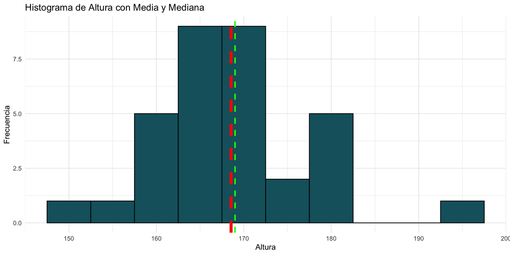

```r
ggplot(datos_curso,
       aes(x = altura)) +
  geom_histogram(binwidth = 5,
                 fill = "#15616D",
                 color = "black") +
  geom_vline(aes(xintercept = media_altura),
             color = "red",
             linetype = "dashed",
             size = 2) +
  geom_vline(aes(xintercept = mediana_altura),
             color = "green",
             linetype = "dashed",
             size = 1) +
  labs(title = "Histograma de Altura con Media y Mediana",
       x = "Altura",
       y = "Frecuencia") +
  theme_minimal()
```

## Desviación Típica o Estándar

##### Desviación Estándar Poblacional (σ):

Se denota con la letra griega sigma (σ). La desviación estándar ($\sigma$) mide la dispersión de los datos respecto a la media poblacional.

$$\sigma = \sqrt{\frac{\sum_{i=1}^{N} (x_i - \mu)^2}{N}}$$

## Desviación Típica o Estándar-cont

#### Muestral: Se denota con la letra latina (s).

La desviación estándar $(s)$ mide la dispersión de los datos respecto a la media muestral y se usa la Corrección de Bessel $(n−1)$ para calcularla.

$$s = \sqrt{\frac{\sum_{i=1}^{n} (x_i - \bar{x})^2}{n-1}}$$

```r
sd_altura <- sd(datos_curso$altura)
sd_altura
```

```
[1] 8.867394
```

## Histograma de Altura

#### con línea media (rojo), 1 desviación estándar (azul) y 2 desviaciones estándar (verde)

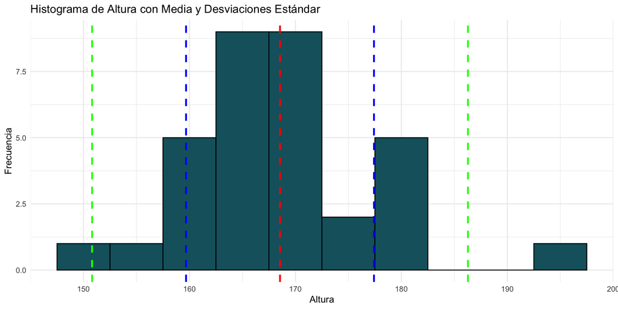

```r
ggplot(datos_curso,
       aes(x = altura)) +
  geom_histogram(binwidth = 5,
                 fill = "#15616D",
                 color = "black") +
  geom_vline(aes(xintercept = media_altura),
             color = "red",
             linetype = "dashed",
             size = 1) +
  geom_vline(aes(xintercept = media_altura + sd_altura),
             color = "blue",
             linetype = "dashed",
             size = 1) +
  geom_vline(aes(xintercept = media_altura - sd_altura),
             color = "blue",
             linetype = "dashed",
             size = 1) +
  geom_vline(aes(xintercept = media_altura + 2 * sd_altura),
             color = "green",
             linetype = "dashed",
             size = 1) +
  geom_vline(aes(xintercept = media_altura - 2 * sd_altura),
             color = "green",
             linetype = "dashed",
             size = 1) +
  labs(title = "Histograma de Altura con Media y Desviaciones Estándar",
       x = "Altura",
       y = "Frecuencia") +
  theme_minimal()
```

## Regresamos: Histograma de altura con mediana

Mediana en verde

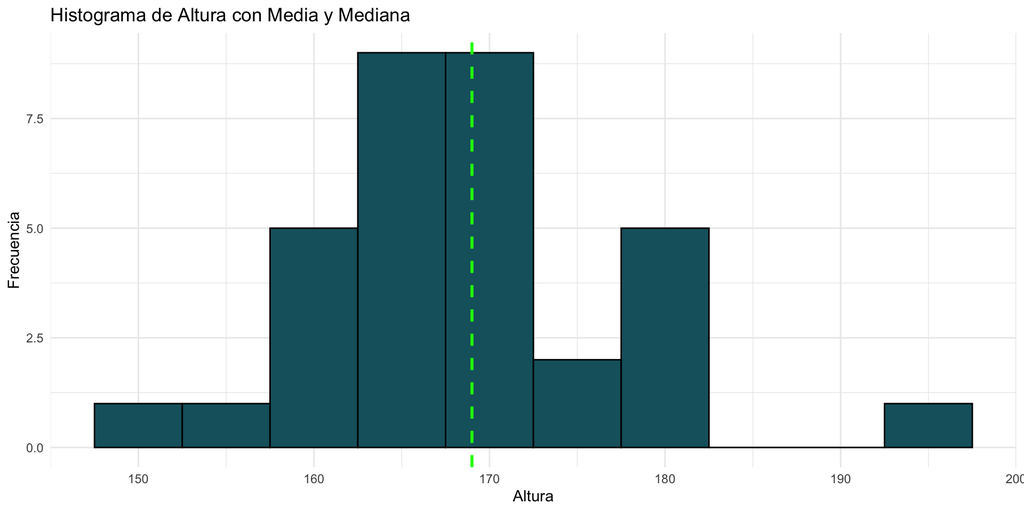

```r
ggplot(datos_curso,
       aes(x = altura)) +
  geom_histogram(binwidth = 5,
                 fill = "#15616D",
                 color = "black") +
  geom_vline(aes(xintercept = mediana_altura),
             color = "green",
             linetype = "dashed",
             size = 1) +
  labs(title = "Histograma de Altura con Media y Mediana",
       x = "Altura",
       y = "Frecuencia") +
  theme_minimal()
```

## Boxplot

El Boxplot visualiza los cuartiles.

- Caja: Del $Q_1$ al $Q_3$ (contiene el 50% central).
- Línea central: Mediana.
- Bigotes: Se extienden hasta 1.5×IQR.
- Puntos: Valores fuera de los bigotes (Outliers).

## Boxplot en representación horizontal y tabla sumario de altura

```r
summary(datos_curso$altura)
```

```
   Min. 1st Qu.  Median    Mean 3rd Qu.    Max.
  152.0   163.0   169.0   168.5   172.0   195.0
```

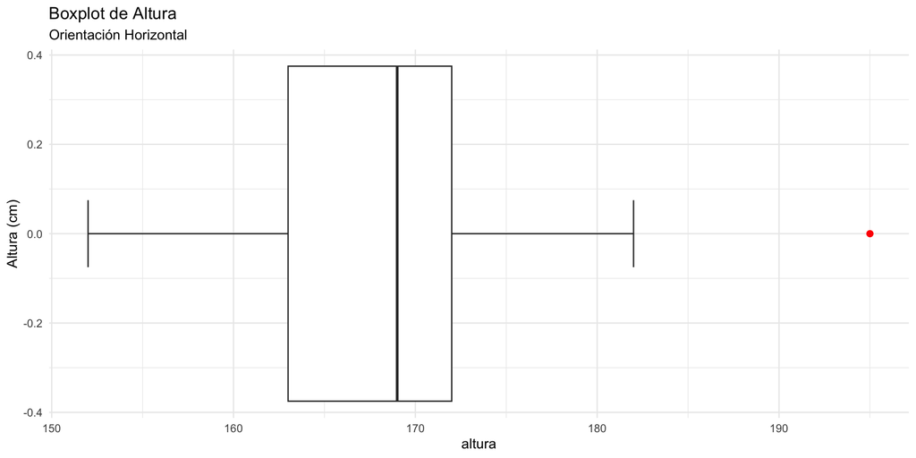

```r
ggplot(datos_curso, aes(y = altura)) +
  geom_boxplot(outlier.colour = "red",
               outlier.size = 2,
               whisker.colour = 'blue',
               staplewidth = 0.2) +
  coord_flip() +
  theme_minimal()+
  labs(title = "Boxplot de Altura",
       subtitle =  'Orientación Horizontal',
       x = "Altura (cm)") +
  theme_minimal()
```

## Representación Conjunta Histograma- Boxplot

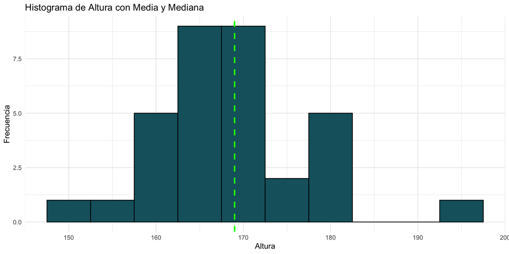

```r
ggplot(datos_curso,
       aes(x = altura)) +
  geom_histogram(binwidth = 5,
                 fill = "#15616D",
                 color = "black") +
  geom_vline(aes(xintercept = mediana_altura),
             color = "green",
             linetype = "dashed",
             size = 1) +
  labs(title = "Histograma de Altura con Media y Mediana",
       x = "Altura",
       y = "Frecuencia") +
  theme_minimal()
```

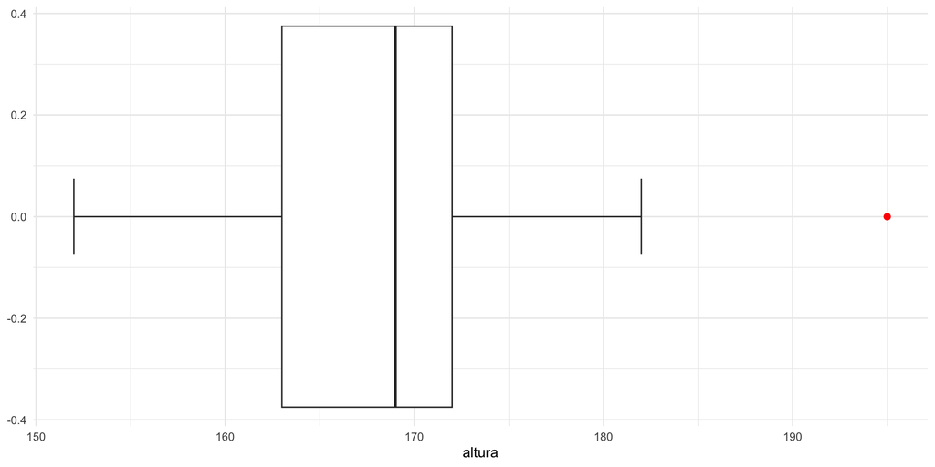

```r
ggplot(datos_curso, aes(y = altura)) +
  geom_boxplot(outlier.colour = "red",
               outlier.size = 2,
               whisker.colour = 'blue',
               staplewidth = 0.2) +
  coord_flip() +
  theme_minimal()
```

## Boxplot de altura

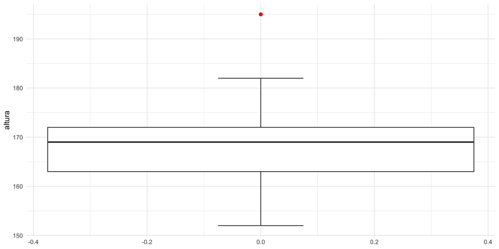

```r
ggplot(datos_curso, aes(y = altura)) +
  geom_boxplot(outlier.colour = "red",
               outlier.size = 2,
               whisker.colour = 'blue',
               staplewidth = 0.2) +
  theme_minimal()
```

## Boxplot de altura por sexo

¿Cómo se comporta la distribución según el sexo?

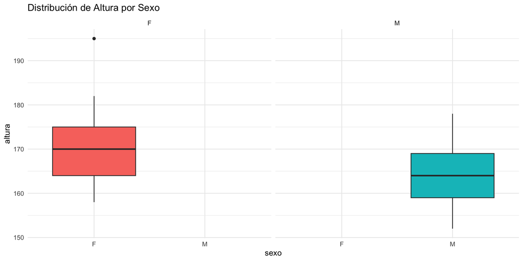

```r
ggplot(datos_curso, aes(x = sexo,
                        y = altura,
                        fill=sexo)) +
  geom_boxplot() +
  facet_grid(~sexo) +
  theme_minimal()+
  labs(title = "Distribución de Altura por Sexo") +
  theme_minimal() +
  theme(legend.position = "none")
```

## Scatterplot: peso vs estatura

Variables posiblemente asociadas

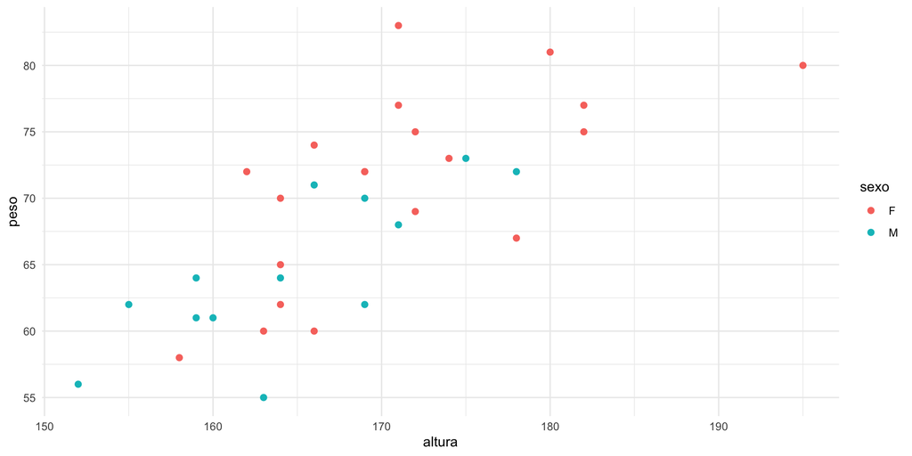

```r
ggplot(datos_curso, aes(x = altura,
                  y = peso,
                  color=sexo)) +
  geom_point(size=2) +
  theme_minimal()
```